# Microplastics Intercalibration Study Data Analysis: Matrix Comparisons, Microscopy, Particles < 20µm Only

Southern California Coastal Water Research Project, University of Toronto & State Water Resources Control Board of California

19 September, 2022

[figure not shown]

# 1 Spiking Summary

Average Number of Spiked Particles per Sample

| Matrix | Plastic? | Number of Spiked Particles | Standard Deviation |
| --- | --- | --- | --- |
| Clean Water | Y | 316.8 | 92.51 |
| Fish Tissue | Y | 360.0 | 24.24 |
| Sediment | Y | 360.0 | 0.00 |

Average Number of Spiked Particles per Sample by Size Fraction

| Matrix | Plastic? | Size Fraction | Number of Spiked Particles | Standard Deviation |
| --- | --- | --- | --- | --- |
| Clean Water | Y | 1-20 µm | 316.8 | 92.51 |
| Fish Tissue | Y | 1-20 µm | 360.0 | 24.24 |
| Sediment | Y | 1-20 µm | 360.0 | 0.00 |

Average Number of Spiked Particles per Sample by Color

| Matrix | Plastic? | Color | Number of Spiked Particles | Standard Deviation |
| --- | --- | --- | --- | --- |
| Clean Water | Y | White | 316.8 | 92.51 |
| Fish Tissue | Y | White | 360.0 | 24.24 |
| Sediment | Y | White | 360.0 | 0.00 |

Average Number of Spiked Particles per Sample by Morphology

| Matrix | Plastic? | Morphology | Number of Spiked Particles | Standard Deviation |
| --- | --- | --- | --- | --- |
| Clean Water | Y | Fragment | 316.8 | 92.51 |
| Fish Tissue | Y | Fragment | 360.0 | 24.24 |
| Sediment | Y | Fragment | 360.0 | 0.00 |

Average Number of Spiked Particles per Sample by Morphology & Color Within Size Fraction

| Matrix | Plastic? | Morphology | Color | Size Fraction | Number of Spiked Particles | Standard Deviation |
| --- | --- | --- | --- | --- | --- | --- |
| Clean Water | Y | Fragment | White | 1-20 µm | 316.8 | 92.51 |
| Fish Tissue | Y | Fragment | White | 1-20 µm | 360.0 | 24.24 |
| Sediment | Y | Fragment | White | 1-20 µm | 360.0 | 0.00 |

# 2 Counts

The following section describes data as absolute particle counts that were reported in each sample. Note that Dirty Water samples were not spiked with any particles less than 212µm and are therefore distinct from the other matrices.

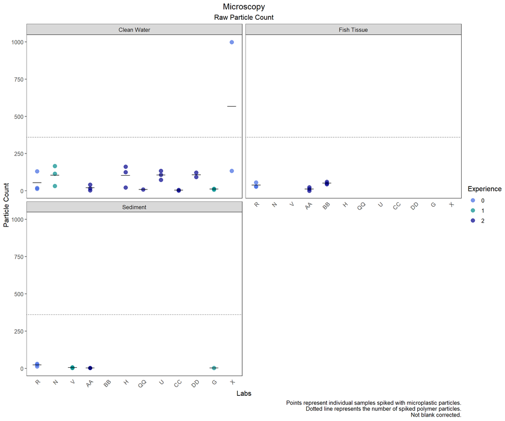

Raw Particle Count. Summary statistics by sample (n = 1-3 samples). Not blank corrected.

| Matrix | Lab ID | Sample ID | Total Particles |
| --- | --- | --- | --- |
| Sediment | V | V_SD_1 | 6 |
| Sediment | V | V_SD_2 | 2 |
| Sediment | V | V_SD_3 | 7 |
| Sediment | R | R_SD_3 | 31 |
| Sediment | R | R_SD_1 | 25 |
| Sediment | R | R_SD_2 | 13 |
| Fish Tissue | R | R_FT_1 | 56 |
| Fish Tissue | R | R_FT_2 | 30 |
| Fish Tissue | R | R_FT_3 | 28 |
| Fish Tissue | AA | AA_FT_1 | 24 |
| Fish Tissue | AA | AA_FT_2 | 12 |
| Fish Tissue | AA | AA_FT_3 | 1 |
| Sediment | AA | AA_SD_1 | 2 |
| Sediment | AA | AA_SD_2 | 3 |
| Sediment | AA | AA_SD_3 | 3 |
| Sediment | G | G_SD_1 | 3 |
| Fish Tissue | BB | BB_FT_6 | 60 |
| Fish Tissue | BB | BB_FT_5 | 50 |
| Fish Tissue | BB | BB_FT_7 | 45 |
| Clean Water | N | N_CW_1 | 33 |
| Clean Water | N | N_CW_3 | 115 |
| Clean Water | N | N_CW_2 | 166 |
| Clean Water | G | G_CW_1 | 14 |
| Clean Water | G | G_CW_2 | 13 |
| Clean Water | G | G_CW_3 | 8 |
| Clean Water | U | U_CW_1 | 108 |
| Clean Water | U | U_CW_2 | 135 |
| Clean Water | U | U_CW_3 | 74 |
| Clean Water | AA | AA_CW_1 | 3 |
| Clean Water | AA | AA_CW_2 | 16 |
| Clean Water | AA | AA_CW_3 | 42 |
| Clean Water | X | X_CW_1 | 999 |
| Clean Water | X | X_CW_2 | 135 |
| Clean Water | R | R_CW_1 | 132 |
| Clean Water | R | R_CW_2 | 13 |
| Clean Water | R | R_CW_3 | 20 |
| Clean Water | DD | DD_CW_2 | 93 |
| Clean Water | DD | DD_CW_3 | 123 |
| Clean Water | H | H_CW_1 | 125 |
| Clean Water | H | H_CW_2 | 162 |
| Clean Water | H | H_CW_3 | 23 |
| Clean Water | QQ | QQ_CW_1 | 9 |
| Clean Water | CC | CC_CW_1 | 2 |
| Clean Water | CC | CC_CW_3 | 6 |

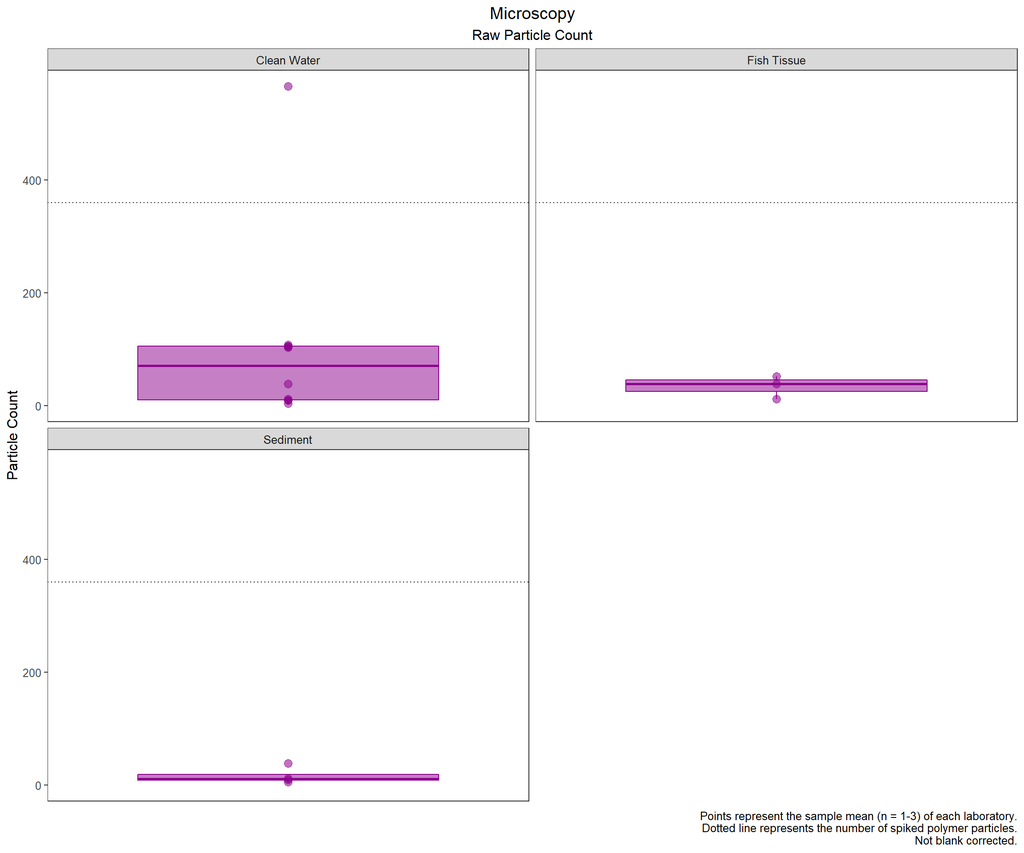

Raw Particle Count. Summary statistics by laboratory (n = 1-3 samples). Not blank corrected.

| Matrix | Lab ID | Mean | Median | SD | Min | Max |
| --- | --- | --- | --- | --- | --- | --- |
| Clean Water | AA | 20.33 | 16.0 | 19.86 | 3 | 42 |
| Clean Water | CC | 4.00 | 4.0 | 2.83 | 2 | 6 |
| Clean Water | DD | 108.00 | 108.0 | 21.21 | 93 | 123 |
| Clean Water | G | 11.67 | 13.0 | 3.21 | 8 | 14 |
| Clean Water | H | 103.33 | 125.0 | 71.99 | 23 | 162 |
| Clean Water | N | 104.67 | 115.0 | 67.10 | 33 | 166 |
| Clean Water | QQ | 9.00 | 9.0 | NA | 9 | 9 |
| Clean Water | R | 55.00 | 20.0 | 66.78 | 13 | 132 |
| Clean Water | U | 105.67 | 108.0 | 30.57 | 74 | 135 |
| Clean Water | X | 567.00 | 567.0 | 610.94 | 135 | 999 |
| Fish Tissue | AA | 12.33 | 12.0 | 11.50 | 1 | 24 |
| Fish Tissue | BB | 51.67 | 50.0 | 7.64 | 45 | 60 |
| Fish Tissue | R | 38.00 | 30.0 | 15.62 | 28 | 56 |
| Sediment | AA | 2.50 | 2.5 | 0.71 | 2 | 3 |
| Sediment | G | 3.00 | 3.0 | NA | 3 | 3 |
| Sediment | R | 23.00 | 25.0 | 9.17 | 13 | 31 |
| Sediment | V | 5.00 | 6.0 | 2.65 | 2 | 7 |

Raw Particle Count. Global summary statistics. Not blank corrected.

| Matrix | Mean | Median | SD | Min | Max |
| --- | --- | --- | --- | --- | --- |
| Clean Water | 108.87 | 79.17 | 167.03 | 4.00 | 567.00 |
| Fish Tissue | 34.00 | 38.00 | 19.97 | 12.33 | 51.67 |
| Sediment | 8.38 | 4.00 | 9.81 | 2.50 | 23.00 |

# 3 Clean Water, Fish Tissue and Sediment Comparisons

Clean Water, Fish Tissue and Sediment samples were spiked with the same materials. Therefore, comparisons may be made for all particle types.

## 3.1 Recovery

The following plots display the recovery (reported count/spiked count (%)) obtained from microscopy. **Reported particle characteristics must match expected particle characteristics of the spiking materials to count towards recovery estimations.** For example, the colors of polymer spiking materials are defined as white, orange, blue, clear and green. Colors outside of these definitions are not included in this section (see Counts).

The dotted line is at 100% and the grey area represents the mean RSD for each given category. The data are **not** blank corrected.

Recovery in this section is estimated based on a single particle characteristic. For example, if the sample was spiked with 10 green particles and 8 green particles were recovered, recovery is estimated as 80% regardless of whether or not the shape or size fraction also matches the spiking material. More restrictive recovery analysis are reported later on in this document.

### 3.1.1 Total

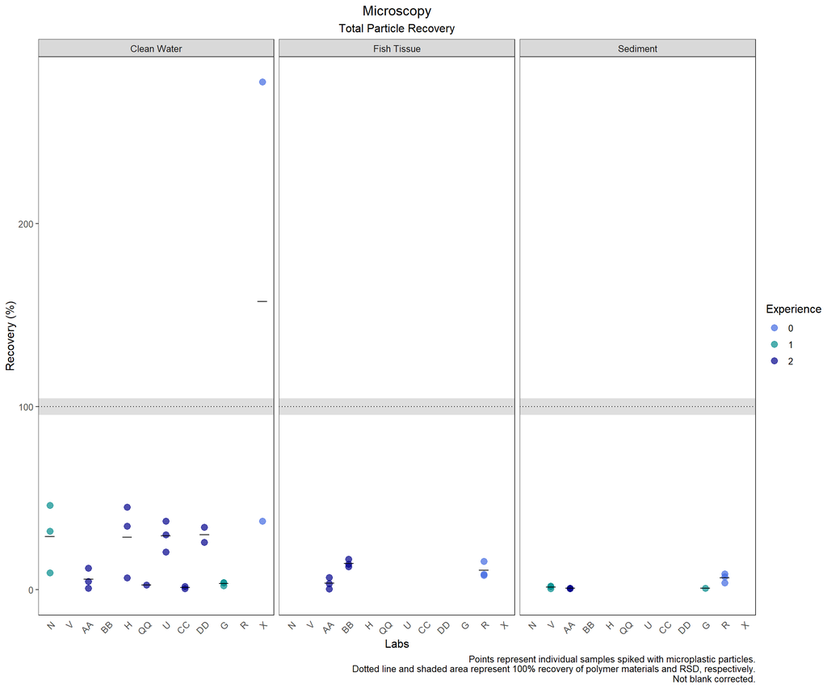

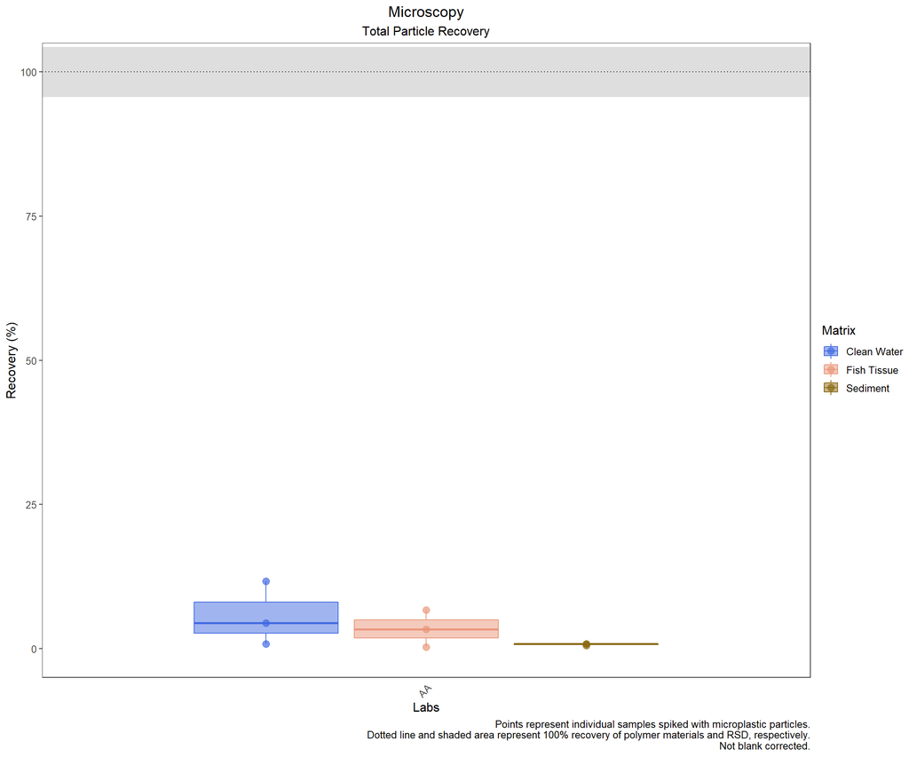

Microscopy: Total Particle Recovery. Summary statistics by sample (n = 1-3 samples). Not blank corrected.

| Matrix | Lab ID | Sample ID | Recovery |
| --- | --- | --- | --- |
| Clean Water | AA | AA_CW_1 | 0.83 |
| Clean Water | AA | AA_CW_2 | 4.44 |
| Clean Water | AA | AA_CW_3 | 11.67 |
| Clean Water | CC | CC_CW_1 | 0.56 |
| Clean Water | CC | CC_CW_3 | 1.67 |
| Clean Water | DD | DD_CW_2 | 25.83 |
| Clean Water | DD | DD_CW_3 | 34.17 |
| Clean Water | G | G_CW_1 | 3.89 |
| Clean Water | G | G_CW_2 | 3.61 |
| Clean Water | G | G_CW_3 | 2.22 |
| Clean Water | H | H_CW_1 | 34.72 |
| Clean Water | H | H_CW_2 | 45.00 |
| Clean Water | H | H_CW_3 | 6.39 |
| Clean Water | N | N_CW_1 | 9.17 |
| Clean Water | N | N_CW_2 | 46.11 |
| Clean Water | N | N_CW_3 | 31.94 |
| Clean Water | QQ | QQ_CW_1 | 2.50 |
| Clean Water | U | U_CW_1 | 30.00 |
| Clean Water | U | U_CW_2 | 37.50 |
| Clean Water | U | U_CW_3 | 20.56 |
| Clean Water | X | X_CW_1 | 277.50 |
| Clean Water | X | X_CW_2 | 37.50 |
| Fish Tissue | AA | AA_FT_1 | 6.67 |
| Fish Tissue | AA | AA_FT_2 | 3.33 |
| Fish Tissue | AA | AA_FT_3 | 0.28 |
| Fish Tissue | BB | BB_FT_5 | 13.89 |
| Fish Tissue | BB | BB_FT_6 | 16.67 |
| Fish Tissue | BB | BB_FT_7 | 12.50 |
| Fish Tissue | R | R_FT_1 | 15.56 |
| Fish Tissue | R | R_FT_2 | 8.33 |
| Fish Tissue | R | R_FT_3 | 7.78 |
| Sediment | AA | AA_SD_1 | 0.56 |
| Sediment | AA | AA_SD_2 | 0.83 |
| Sediment | AA | AA_SD_3 | 0.83 |
| Sediment | G | G_SD_1 | 0.83 |
| Sediment | R | R_SD_1 | 6.94 |
| Sediment | R | R_SD_2 | 3.61 |
| Sediment | R | R_SD_3 | 8.61 |
| Sediment | V | V_SD_1 | 1.67 |
| Sediment | V | V_SD_2 | 0.56 |
| Sediment | V | V_SD_3 | 1.94 |

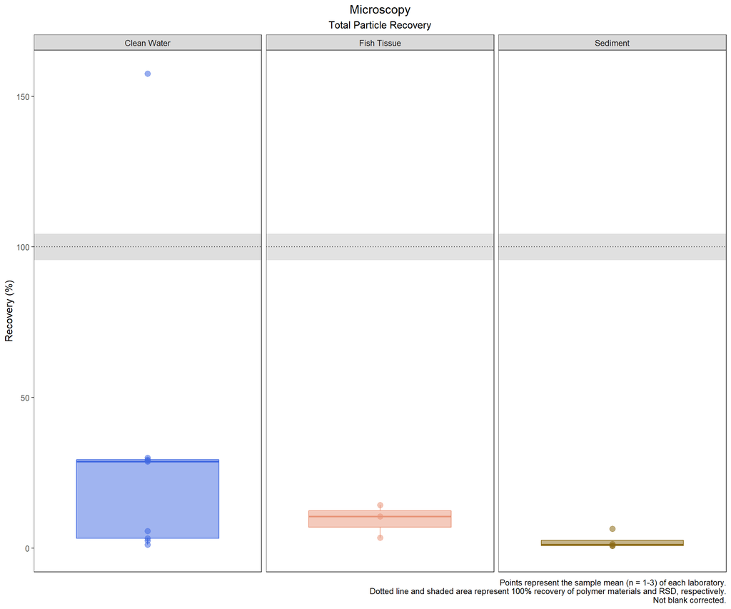

Microscopy: Total Particle Recovery. Summary statistics by laboratory (n = 1-3 samples). Not blank corrected.

| Matrix | Lab ID | Mean (%) | Median (%) | SD (%) | SE (%) | Min (%) | Max (%) |
| --- | --- | --- | --- | --- | --- | --- | --- |
| Clean Water | AA | 5.65 | 4.44 | 5.52 | 3.18 | 0.83 | 11.67 |
| Fish Tissue | AA | 3.43 | 3.33 | 3.20 | 1.84 | 0.28 | 6.67 |
| Sediment | AA | 0.74 | 0.83 | 0.16 | 0.09 | 0.56 | 0.83 |
| Fish Tissue | BB | 14.35 | 13.89 | 2.12 | 1.22 | 12.50 | 16.67 |
| Clean Water | CC | 1.11 | 1.11 | 0.79 | 0.56 | 0.56 | 1.67 |
| Clean Water | DD | 30.00 | 30.00 | 5.89 | 4.17 | 25.83 | 34.17 |
| Clean Water | G | 3.24 | 3.61 | 0.89 | 0.52 | 2.22 | 3.89 |
| Sediment | G | 0.83 | 0.83 | NA | NA | 0.83 | 0.83 |
| Clean Water | H | 28.70 | 34.72 | 20.00 | 11.55 | 6.39 | 45.00 |
| Clean Water | N | 29.07 | 31.94 | 18.64 | 10.76 | 9.17 | 46.11 |
| Clean Water | QQ | 2.50 | 2.50 | NA | NA | 2.50 | 2.50 |
| Fish Tissue | R | 10.56 | 8.33 | 4.34 | 2.51 | 7.78 | 15.56 |
| Sediment | R | 6.39 | 6.94 | 2.55 | 1.47 | 3.61 | 8.61 |
| Clean Water | U | 29.35 | 30.00 | 8.49 | 4.90 | 20.56 | 37.50 |
| Sediment | V | 1.39 | 1.67 | 0.73 | 0.42 | 0.56 | 1.94 |
| Clean Water | X | 157.50 | 157.50 | 169.71 | 120.00 | 37.50 | 277.50 |

Microscopy: Total Particle Recovery. Summary statistics across all laboratories. Not blank corrected.

| Matrix | Mean (%) | Median (%) | SD (%) | SE (%) | Min (%) | Max (%) |
| --- | --- | --- | --- | --- | --- | --- |
| Clean Water | 31.90 | 28.70 | 48.90 | 16.30 | 1.11 | 157.50 |
| Fish Tissue | 9.44 | 10.56 | 5.55 | 3.20 | 3.43 | 14.35 |
| Sediment | 2.34 | 1.11 | 2.72 | 1.36 | 0.74 | 6.39 |

### 3.1.2 Size Fraction

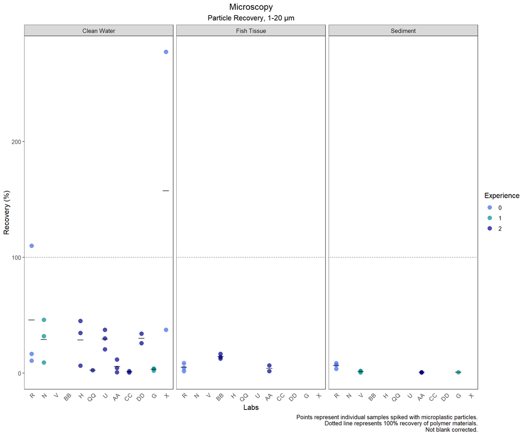

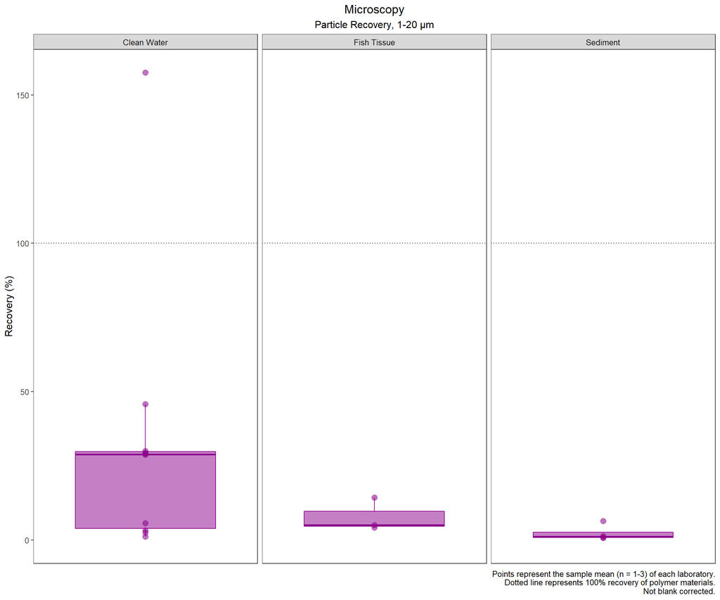

### 3.1.3 Color

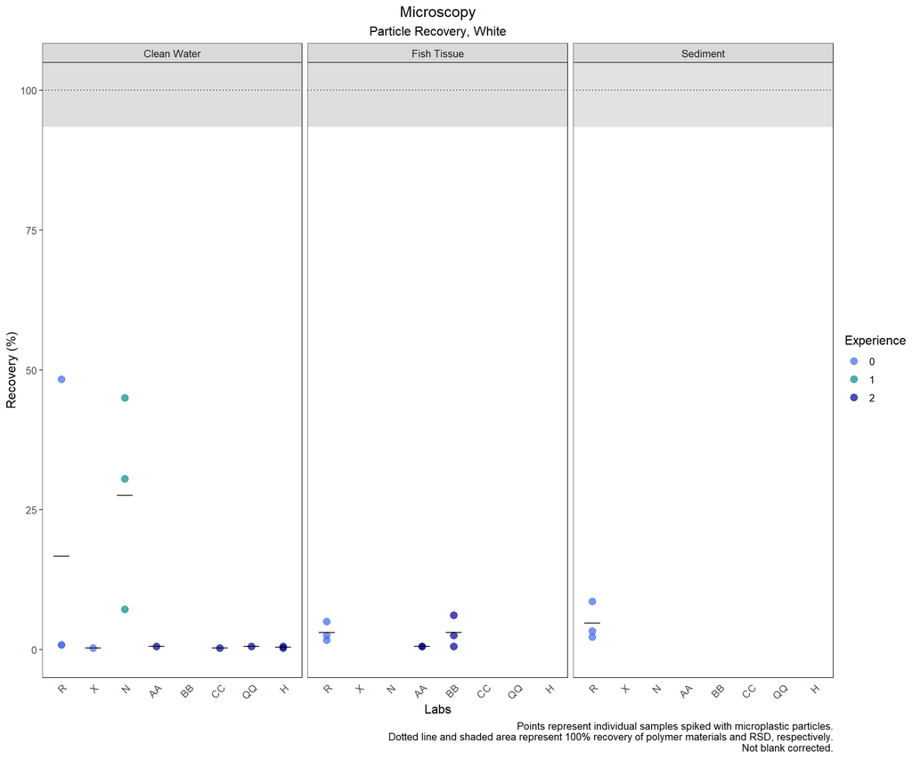

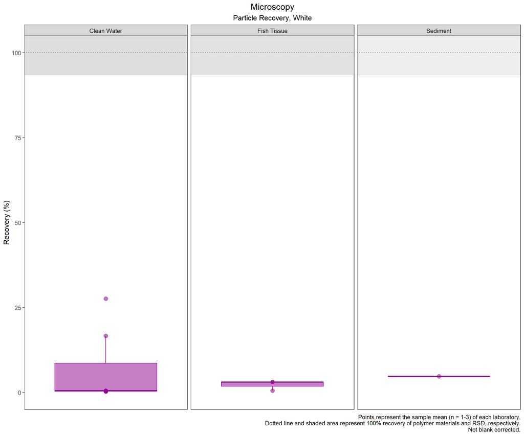

### 3.1.4 Morphology

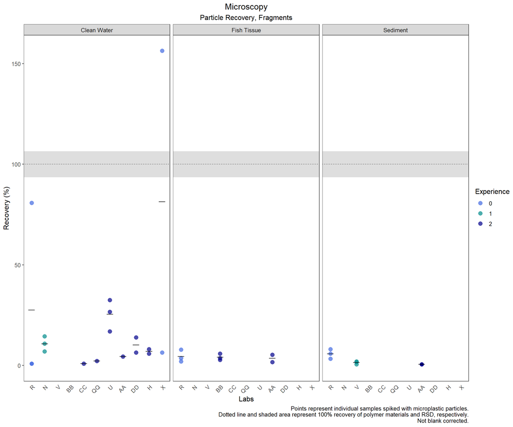

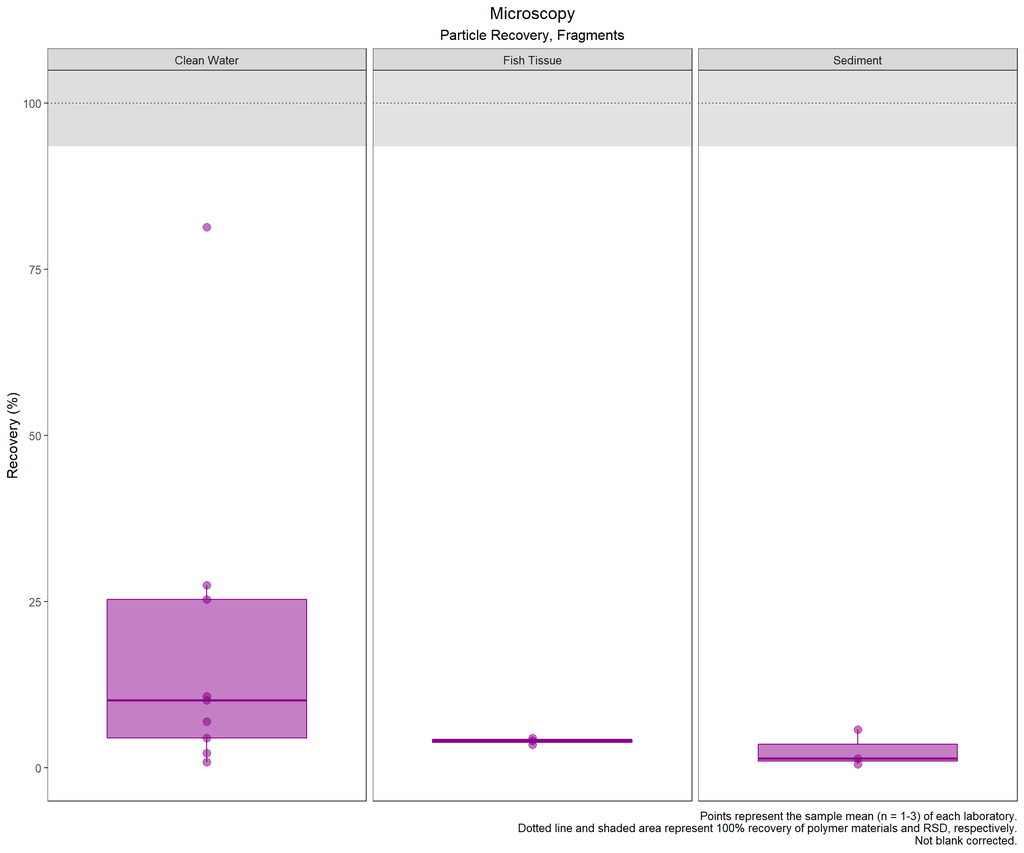

| Matrix | Lab ID | Sample ID | Morphology | Recovery |
| --- | --- | --- | --- | --- |
| Clean Water | AA | AA_CW_3 | Fragment | 4.44 |
| Clean Water | CC | CC_CW_3 | Fragment | 0.83 |
| Clean Water | DD | DD_CW_2 | Fragment | 6.39 |
| Clean Water | DD | DD_CW_3 | Fragment | 13.89 |
| Clean Water | H | H_CW_1 | Fragment | 8.06 |
| Clean Water | H | H_CW_2 | Fragment | 5.83 |
| Clean Water | N | N_CW_1 | Fragment | 6.94 |
| Clean Water | N | N_CW_2 | Fragment | 14.44 |
| Clean Water | N | N_CW_3 | Fragment | 10.83 |
| Clean Water | QQ | QQ_CW_1 | Fragment | 2.22 |
| Clean Water | R | R_CW_1 | Fragment | 80.83 |
| Clean Water | R | R_CW_2 | Fragment | 0.83 |
| Clean Water | R | R_CW_3 | Fragment | 0.83 |
| Clean Water | U | U_CW_1 | Fragment | 26.67 |
| Clean Water | U | U_CW_2 | Fragment | 32.50 |
| Clean Water | U | U_CW_3 | Fragment | 16.94 |
| Clean Water | X | X_CW_1 | Fragment | 156.39 |
| Clean Water | X | X_CW_2 | Fragment | 6.39 |
| Fish Tissue | AA | AA_FT_1 | Fragment | 5.28 |
| Fish Tissue | AA | AA_FT_2 | Fragment | 1.67 |
| Fish Tissue | BB | BB_FT_5 | Fragment | 3.61 |
| Fish Tissue | BB | BB_FT_6 | Fragment | 5.83 |
| Fish Tissue | BB | BB_FT_7 | Fragment | 2.78 |
| Fish Tissue | R | R_FT_1 | Fragment | 7.78 |
| Fish Tissue | R | R_FT_2 | Fragment | 3.61 |
| Fish Tissue | R | R_FT_3 | Fragment | 1.94 |
| Sediment | AA | AA_SD_1 | Fragment | 0.56 |
| Sediment | AA | AA_SD_2 | Fragment | 0.56 |
| Sediment | AA | AA_SD_3 | Fragment | 0.56 |
| Sediment | R | R_SD_1 | Fragment | 5.83 |
| Sediment | R | R_SD_2 | Fragment | 3.33 |
| Sediment | R | R_SD_3 | Fragment | 8.06 |
| Sediment | V | V_SD_1 | Fragment | 1.67 |
| Sediment | V | V_SD_2 | Fragment | 0.56 |
| Sediment | V | V_SD_3 | Fragment | 1.94 |

Microscopy: Total Particle Recovery by Morphology. Summary statistics by laboratory (n = 1-3 samples). Not blank corrected.

| Matrix | Lab ID | Morphology | Mean (%) | Median (%) | SD (%) | SE (%) | Min (%) | Max (%) |
| --- | --- | --- | --- | --- | --- | --- | --- | --- |
| Clean Water | AA | Fragment | 4.44 | 4.44 | NA | NA | 4.44 | 4.44 |
| Fish Tissue | AA | Fragment | 3.47 | 3.47 | 2.55 | 1.81 | 1.67 | 5.28 |
| Sediment | AA | Fragment | 0.56 | 0.56 | 0.00 | 0.00 | 0.56 | 0.56 |
| Fish Tissue | BB | Fragment | 4.07 | 3.61 | 1.58 | 0.91 | 2.78 | 5.83 |
| Clean Water | CC | Fragment | 0.83 | 0.83 | NA | NA | 0.83 | 0.83 |
| Clean Water | DD | Fragment | 10.14 | 10.14 | 5.30 | 3.75 | 6.39 | 13.89 |
| Clean Water | H | Fragment | 6.94 | 6.94 | 1.57 | 1.11 | 5.83 | 8.06 |
| Clean Water | N | Fragment | 10.74 | 10.83 | 3.75 | 2.17 | 6.94 | 14.44 |
| Clean Water | QQ | Fragment | 2.22 | 2.22 | NA | NA | 2.22 | 2.22 |
| Clean Water | R | Fragment | 27.50 | 0.83 | 46.19 | 26.67 | 0.83 | 80.83 |
| Fish Tissue | R | Fragment | 4.44 | 3.61 | 3.00 | 1.73 | 1.94 | 7.78 |
| Sediment | R | Fragment | 5.74 | 5.83 | 2.36 | 1.36 | 3.33 | 8.06 |
| Clean Water | U | Fragment | 25.37 | 26.67 | 7.86 | 4.54 | 16.94 | 32.50 |
| Sediment | V | Fragment | 1.39 | 1.67 | 0.73 | 0.42 | 0.56 | 1.94 |
| Clean Water | X | Fragment | 81.39 | 81.39 | 106.07 | 75.00 | 6.39 | 156.39 |

Microscopy: Total Particle Recovery by Morphology. Summary statistics across all laboratories. Not blank corrected.

| Matrix | Morphology | Mean (%) | Median (%) | SD (%) | SE (%) | Min (%) | Max (%) |
| --- | --- | --- | --- | --- | --- | --- | --- |
| Clean Water | Fragment | 21.96 | 7.50 | 38.46 | 9.06 | 0.83 | 156.39 |
| Fish Tissue | Fragment | 4.06 | 3.61 | 2.09 | 0.74 | 1.67 | 7.78 |
| Sediment | Fragment | 2.56 | 1.67 | 2.71 | 0.90 | 0.56 | 8.06 |

### 3.1.5 Color and Morphology within Size Fraction

The following plots display the recovery (reported count/spiked count (%)) obtained from microscopy. **Reported particle characteristics must match expected particle characteristics of the spiking materials to count towards recovery estimations.** For example, the colors of polymer spiking materials are defined as white, orange, blue, clear and green. Colors outside of these definitions are currently excluded from analysis.

The dotted line is at 100% and the grey area represents the mean RSD for each given category. The data are **not** blank corrected.

Recovery in this section is estimated based on color and morphology within a size fraction. For example, if the sample was spiked with 10 green spheres >500 µm and 8 green spheres were recovered in the >500 µm size fraction, recovery is estimated as 80%. However, if 4 of these spheres were reported as blue rather than green, recovery would fall to 60%.

1-20 µm White Fragment

| Matrix | Lab ID | Sample ID | Recovery |
| --- | --- | --- | --- |
| Clean Water | AA | AA_CW_3 | 0.56 |
| Fish Tissue | AA | AA_FT_1 | 0.56 |
| Fish Tissue | BB | BB_FT_5 | 1.94 |
| Fish Tissue | BB | BB_FT_6 | 1.39 |
| Clean Water | CC | CC_CW_3 | 0.28 |
| Clean Water | H | H_CW_1 | 0.28 |
| Clean Water | H | H_CW_2 | 0.56 |
| Clean Water | N | N_CW_1 | 6.94 |
| Clean Water | N | N_CW_2 | 14.44 |
| Clean Water | N | N_CW_3 | 10.83 |
| Clean Water | QQ | QQ_CW_1 | 0.28 |
| Clean Water | R | R_CW_1 | 47.50 |
| Clean Water | R | R_CW_2 | 0.83 |
| Clean Water | R | R_CW_3 | 0.83 |
| Fish Tissue | R | R_FT_1 | 4.72 |
| Fish Tissue | R | R_FT_2 | 2.50 |
| Fish Tissue | R | R_FT_3 | 1.67 |
| Sediment | R | R_SD_1 | 2.22 |
| Sediment | R | R_SD_2 | 3.33 |
| Sediment | R | R_SD_3 | 8.06 |

1-20 µm White Fragment

| Matrix | Lab ID | Mean (%) | Median (%) | SD (%) | SE (%) | Min (%) | Max (%) |
| --- | --- | --- | --- | --- | --- | --- | --- |
| Clean Water | AA | 0.56 | 0.56 | NA | NA | 0.56 | 0.56 |
| Fish Tissue | AA | 0.56 | 0.56 | NA | NA | 0.56 | 0.56 |
| Fish Tissue | BB | 1.67 | 1.67 | 0.39 | 0.28 | 1.39 | 1.94 |
| Clean Water | CC | 0.28 | 0.28 | NA | NA | 0.28 | 0.28 |
| Clean Water | H | 0.42 | 0.42 | 0.20 | 0.14 | 0.28 | 0.56 |
| Clean Water | N | 10.74 | 10.83 | 3.75 | 2.17 | 6.94 | 14.44 |
| Clean Water | QQ | 0.28 | 0.28 | NA | NA | 0.28 | 0.28 |
| Clean Water | R | 16.39 | 0.83 | 26.94 | 15.56 | 0.83 | 47.50 |
| Fish Tissue | R | 2.96 | 2.50 | 1.58 | 0.91 | 1.67 | 4.72 |
| Sediment | R | 4.54 | 3.33 | 3.10 | 1.79 | 2.22 | 8.06 |

1-20 µm White Fragment

| Matrix | Lab ID | Sample ID | Recovery |
| --- | --- | --- | --- |
| Clean Water | AA | AA_CW_3 | 0.56 |
| Fish Tissue | AA | AA_FT_1 | 0.56 |
| Fish Tissue | BB | BB_FT_5 | 1.94 |
| Fish Tissue | BB | BB_FT_6 | 1.39 |
| Clean Water | CC | CC_CW_3 | 0.28 |
| Clean Water | H | H_CW_1 | 0.28 |
| Clean Water | H | H_CW_2 | 0.56 |
| Clean Water | N | N_CW_1 | 6.94 |
| Clean Water | N | N_CW_2 | 14.44 |
| Clean Water | N | N_CW_3 | 10.83 |
| Clean Water | QQ | QQ_CW_1 | 0.28 |
| Clean Water | R | R_CW_1 | 47.50 |
| Clean Water | R | R_CW_2 | 0.83 |
| Clean Water | R | R_CW_3 | 0.83 |
| Fish Tissue | R | R_FT_1 | 4.72 |
| Fish Tissue | R | R_FT_2 | 2.50 |
| Fish Tissue | R | R_FT_3 | 1.67 |
| Sediment | R | R_SD_1 | 2.22 |
| Sediment | R | R_SD_2 | 3.33 |
| Sediment | R | R_SD_3 | 8.06 |

1-20 µm White Fragment

| Matrix | Lab ID | Mean (%) | Median (%) | SD (%) | SE (%) | Min (%) | Max (%) |
| --- | --- | --- | --- | --- | --- | --- | --- |
| Clean Water | AA | 0.56 | 0.56 | NA | NA | 0.56 | 0.56 |
| Fish Tissue | AA | 0.56 | 0.56 | NA | NA | 0.56 | 0.56 |
| Fish Tissue | BB | 1.67 | 1.67 | 0.39 | 0.28 | 1.39 | 1.94 |
| Clean Water | CC | 0.28 | 0.28 | NA | NA | 0.28 | 0.28 |
| Clean Water | H | 0.42 | 0.42 | 0.20 | 0.14 | 0.28 | 0.56 |
| Clean Water | N | 10.74 | 10.83 | 3.75 | 2.17 | 6.94 | 14.44 |
| Clean Water | QQ | 0.28 | 0.28 | NA | NA | 0.28 | 0.28 |
| Clean Water | R | 16.39 | 0.83 | 26.94 | 15.56 | 0.83 | 47.50 |
| Fish Tissue | R | 2.96 | 2.50 | 1.58 | 0.91 | 1.67 | 4.72 |
| Sediment | R | 4.54 | 3.33 | 3.10 | 1.79 | 2.22 | 8.06 |

1-20 µm White Fragment

| Matrix | Lab ID | Sample ID | Recovery |
| --- | --- | --- | --- |
| Clean Water | AA | AA_CW_3 | 0.56 |
| Fish Tissue | AA | AA_FT_1 | 0.56 |
| Fish Tissue | BB | BB_FT_5 | 1.94 |
| Fish Tissue | BB | BB_FT_6 | 1.39 |
| Clean Water | CC | CC_CW_3 | 0.28 |
| Clean Water | H | H_CW_1 | 0.28 |
| Clean Water | H | H_CW_2 | 0.56 |
| Clean Water | N | N_CW_1 | 6.94 |
| Clean Water | N | N_CW_2 | 14.44 |
| Clean Water | N | N_CW_3 | 10.83 |
| Clean Water | QQ | QQ_CW_1 | 0.28 |
| Clean Water | R | R_CW_1 | 47.50 |
| Clean Water | R | R_CW_2 | 0.83 |
| Clean Water | R | R_CW_3 | 0.83 |
| Fish Tissue | R | R_FT_1 | 4.72 |
| Fish Tissue | R | R_FT_2 | 2.50 |
| Fish Tissue | R | R_FT_3 | 1.67 |
| Sediment | R | R_SD_1 | 2.22 |
| Sediment | R | R_SD_2 | 3.33 |
| Sediment | R | R_SD_3 | 8.06 |

1-20 µm White Fragment

| Matrix | Lab ID | Mean (%) | Median (%) | SD (%) | SE (%) | Min (%) | Max (%) |
| --- | --- | --- | --- | --- | --- | --- | --- |
| Clean Water | AA | 0.56 | 0.56 | NA | NA | 0.56 | 0.56 |
| Fish Tissue | AA | 0.56 | 0.56 | NA | NA | 0.56 | 0.56 |
| Fish Tissue | BB | 1.67 | 1.67 | 0.39 | 0.28 | 1.39 | 1.94 |
| Clean Water | CC | 0.28 | 0.28 | NA | NA | 0.28 | 0.28 |
| Clean Water | H | 0.42 | 0.42 | 0.20 | 0.14 | 0.28 | 0.56 |
| Clean Water | N | 10.74 | 10.83 | 3.75 | 2.17 | 6.94 | 14.44 |
| Clean Water | QQ | 0.28 | 0.28 | NA | NA | 0.28 | 0.28 |
| Clean Water | R | 16.39 | 0.83 | 26.94 | 15.56 | 0.83 | 47.50 |
| Fish Tissue | R | 2.96 | 2.50 | 1.58 | 0.91 | 1.67 | 4.72 |
| Sediment | R | 4.54 | 3.33 | 3.10 | 1.79 | 2.22 | 8.06 |

End of Analysis.